# Markov Chain Monte Carlo for Bayesian Inference

April 06, 2020

## Standard Normal to General Normal

- PDF of the standard normal distribution is \(f\left(z\right) = \frac{1}{\sqrt{2\pi}} e^{-\frac{1}{2}z^2}\)
- If \(Z\) is distributed standard normal and \(\sigma > 0\), what is the distribution of \(X\left(Z\right) = \mu + \sigma Z\)?
- \(\Pr\left(Z \leq z\right) = \Pr\left(Z \leq z\left(x\right)\right)\)
- \(z\left(x\right) = \frac{x - \mu}{\sigma}\) whose derivative is \(\frac{\partial}{\partial x} z\left(x\right) = \frac{1}{\sigma}\)
- \(f\left(x \mid \mu, \sigma\right) = \frac{\partial}{\partial x} \Pr\left(Z \leq z\left(x\right)\right) = f\left(z\left(x\right)\right) \times \frac{\partial}{\partial x}z\left(x\right) = \frac{1}{\sigma \sqrt{2\pi}} e^{-\frac{1}{2}\left(\frac{x - \mu}{\sigma}\right)^2}\) which is the PDF for a general normal distribution
- \(\mathbb{E}X = \mu + \sigma \mathbb{E}Z = \mu\)
- \(\mathbb{E}\left(X - \mu\right)^2 = \mathbb{E}\left(\sigma Z\right)^2 = \sigma^2 \mathbb{E}Z^2 = \sigma^2\)

## General Normal to Lognormal

- If \(X\) is distributed normal with expectation \(\mu\) and standard deviation \(\sigma > 0\), what is the PDF of \(Y\left(X\right) = e^{X}\)?
- \(\Pr\left(X \leq x\right) = \Pr\left(X \leq x\left(y\right)\right)\)
- \(x\left(y\right) = \ln y\) whose derivative is \(\frac{\partial}{\partial y}x\left(y\right) = \frac{1}{y}\)
- \(f\left(y \mid \mu, \sigma\right) = f\left(x\left(y\right) \mid \mu, \sigma\right) \times \frac{\partial}{\partial y}x\left(y\right) = \frac{1}{y \sigma \sqrt{2\pi}} e^{-\frac{1}{2}\left(\frac{\ln y - \mu}{\sigma}\right)^2}\) which is the PDF of the lognormal distribution
- \(\mathbb{E}Y = \int_0^\infty e^y f\left(y \mid \mu, \sigma\right) dy = e^{\mu + \frac{\sigma^2}{2}} \neq \mu\)

## Poisson Likelihood with Lognormal Prior

- Taking limits, we can express Bayes’ Rule for continuous random variables with Probability Density Functions (PDFs) \[f\left(B\mid A\right) = \frac{f\left(B\right) f\left(A \mid B\right)}{f\left(A\right)}\]
- The PDF of the lognormal distribution is again \[\color{red}{f\left(\lambda \mid \mu,\sigma\right) = \frac{1}{\lambda \sigma \sqrt{2 \pi}} e^{-\frac{1}{2}\left(\frac{\ln y - \mu}{\sigma}\right)^2}}\]
- Poisson PMF for \(N\) observations with sum \(s\) is \(\color{blue}{f\left(\left.y_1,\dots,y_n\right|\lambda\right) = \frac{\lambda^{s} e^{-N\lambda}}{s!}}\)
- Bayes’ Rule is \(\color{purple}{f\left(\lambda \mid \mu, \sigma, y_1,\dots,y_n\right) \propto k\left(\lambda\right) = } \color{purple}{\lambda^{s - 1} e^{-N\lambda - \frac{1}{2}\left(\frac{\ln \lambda - \mu}{\sigma}\right)^2}}\)
- The denominator of Bayes’ Rule is \(\int_0^\infty k\left(\lambda\right) d\lambda\) but is not elementary

## Posterior PDF

In breakout rooms, one person screenshare and the rest help to write a R function that evaluates the above posterior PDF:

1. Choose arbitrary real values of \(\mu\) and \(\sigma > 0\) integers \(s \geq 0\) and \(N > 0\)
2. Write / wrap a function of \(\lambda\) that evaluates the lognormal prior PDF
3. Write / wrap a function of \(\lambda\) that evaluates the Poisson likelihood at \(N \lambda\)
4. Write a function of \(\lambda\) that multiplies the prior and likelihood together
5. Call the `integrate` function on the function from (4) to compute the denominator of Bayes’ Rule
6. Write a function of \(\lambda\) that calls the function from (4) and divides by the constant from (5)

## R Code for Previous Example

```r
mu <- 0
sigma <- sqrt(2)
s <- 42
N <- 5
prior <- function(lambda) dlnorm(lambda, meanlog = mu, sdlog = sigma)
likelihood <- function(lambda) dpois(s, N * lambda) # note: function of lambda
kernel <- function(lambda) prior(lambda) * likelihood(lambda)
denom <- integrate(kernel, lower = 0, upper = Inf)$value # 0.0022
post <- function(lambda) kernel(lambda) / denom
curve(post(lambda), from = 0, to = 15, xname = "lambda",
      xlab = expression(lambda), ylab = "Posterior PDF")
```

## Plot from Previous Slide

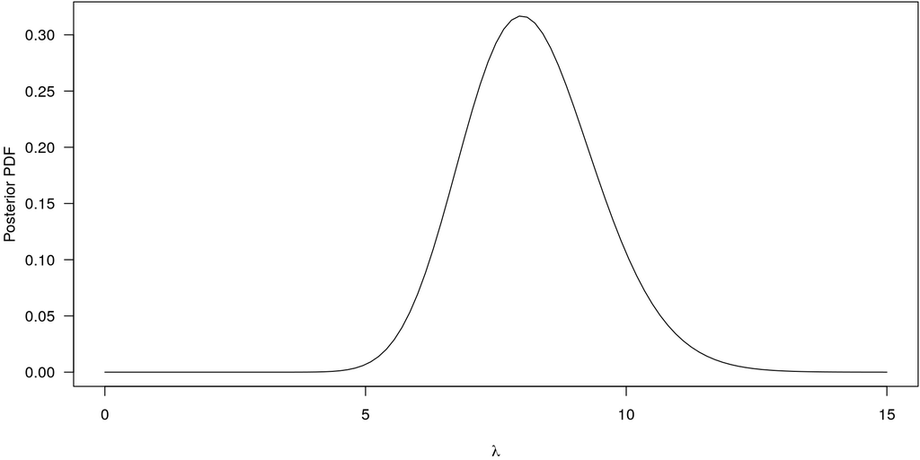

## Drawing from a Uniform Distribution

- Randomness can be harvested from physical sources, but it is expensive
- Modern Intel processors have a (possibly) [true random-number generator](https://en.wikipedia.org/wiki/RdRand)
- In practice, software emulates a true random-number generator for speed
- Let \(M = -1 + 2^{64} = 18,446,744,073,709,551,615\) be the largest unsigned integer that a 64-bit computer can represent. You can essentially draw uniformally from \(\Omega_U = \left[0,1\right)\) by
  1. Drawing \(\tilde{y}\) from \(\Omega_Y = \{0,1,\dots,M\}\) with each probability \(\frac{1.0}{M}\)
  2. Letting \(\tilde{u} = \frac{\tilde{y}}{1.0 + M}\), which casts to a double-precision denominator
- The CDF of the uniform distribution on \(\left(a,b\right)\) is \(F\left(\left.u\right|a,b\right) = \frac{u - a}{b - a}\) and the PDF is \(f\left(\left.u\right|a,b\right) = \frac{1}{b - a}\). Standard is a special case with \(a = 0\) and \(b = 1\).

## Drawing from an Exponential Distribution

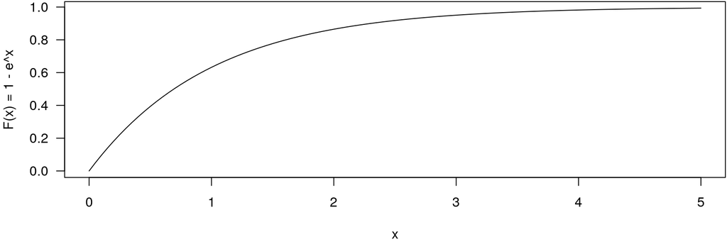

- To draw from this (standard exponential) distribution (a la `rexp`), you could
  1. Draw \(\tilde{u}\) from a standard uniform distribution
  2. Find the point on the curve with height \(\tilde{u}\)
  3. Drop to the horizontal axis at \(\tilde{x}\) to get a standard exponential realization
  4. Optionally scale \(\tilde{x}\) by a given \(\mu > 0\) to make it exponential with rate \(\frac{1}{\mu}\)

## Inverse CDF Sampling of Continuous RVs

- In principle, the previous implies an algorithm to draw from ANY univariate continuous distribution
- If \(U\) is distributed standard uniform, what is the PDF of \(X = F^{-1}\left(U\right)\)?
- \(\Pr\left(U \leq u\right) = u = \Pr\left(U \leq u\left(x\right)\right)\)
- \(u\left(x\right) = F\left(x \mid \boldsymbol{\theta}\right)\) with derivative \(f\left(x \mid \boldsymbol{\theta}\right)\)
- So the PDF of \(X\) is \(1 \times f\left(x \mid \boldsymbol{\theta}\right)\)
- `rnorm(1, mu, sigma)` is implemented by `qnorm(runif(1), mu, sigma)`

## Generalized \(\lambda\) Distribution (GLD)

- GLD is a four parameter (i.e. very flexible) continuous distribution [defined](https://mpra.ub.uni-muenchen.de/43333/3/MPRA_paper_43333.pdf) by its inverse CDF \[F^{-1}\left(u \mid m, r, a, s\right) = m + r \times F^{-1}\left(u \mid a, s\right) = m + r \times \frac{S\left(u \mid a, s\right) - S\left(\frac{1}{2} \mid a, s\right)} {S\left(\frac{3}{4} \mid a, s\right) - S\left(\frac{1}{4} \mid a, s\right)}\] where \(m\) is the median, \(r\) is the inter-quartile range, \(a \in \left(-1, 1\right)\) is an asymmetry parameter, \(s \in \left(0,1\right)\) is a tail steepness parameter, and \(S\left(u \mid a, s\right)\) is a complicated increasing function
- The CDF and PDF of the GLD do not have explicit forms, which is not a problem for us

```r
rstan::expose_stan_functions("quantile_functions.stan") # defines GLD_icdf() and GLD_rng() in R
source("GLD_helpers.R")                                 # brings into R GLD_solver() and GLD_solver_bounded()
args(GLD_solver); args(GLD_solver_bounded)              # these two functions solve for a and s
```

```
## function (lower_quartile, median, upper_quartile, other_quantile,
##     alpha, check = TRUE)
## NULL
```

```
## function (bounds, median, IQR, check = TRUE, ...)
## NULL
```

## Using the Generalized \(\lambda\) Distribution

```r
a_s <- GLD_solver(lower_quartile = log(28), median = log(63.179), upper_quartile = log(125),
                  other_quantile = 0, alpha = 0) # note warning
```

```r
Q <- Vectorize(GLD_icdf, vectorize.args = "p")
curve(exp(Q(u, median = log(63.179), IQR = log(125) - log(28),
            asymmetry = a_s[1], steepness = a_s[2])),
      from = 0, to = 1, xname = "u", xlab = "Income quantile", ylab = "Income", log = "y")
```

## Plot from Previous Slide

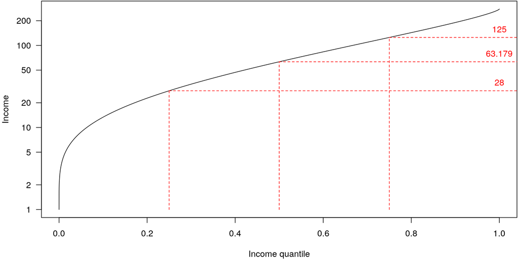

## Using the Bounded Generalized \(\lambda\) Distribution

- What do you think the probability that someone from around NYU who is tested for coronavirus will be positive? What is your prior median and IQR?

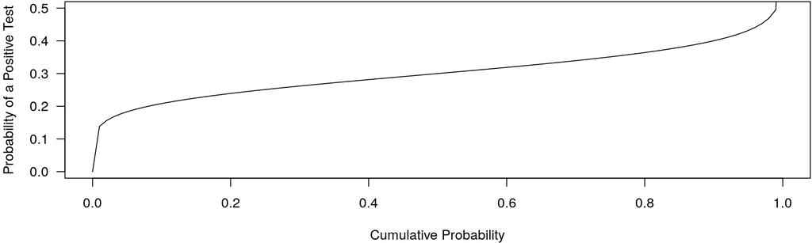

```r
a_s <- GLD_solver_bounded(bounds = 0:1, median = 0.3, IQR = 0.1) # warnings are OK
curve(Q(u, median = 0.3, IQR = 0.1, a_s[1], a_s[2]), from = 0, to = 1, ylim = c(0, 0.5),
      xname = "u", xlab = "Cumulative Probability", ylab = "Probability of a Positive Test")
```

## Prior Predictive Distribution

- The prior predictive distribution, which is the marginal distribution of future data integrated over the parameters, is formed by
  1. Draw \(\widetilde{\theta}\) from its prior distribution
  2. Draw \(\widetilde{y}\) from its conditional distribution given the realization of \(\widetilde{\theta}\)
  3. Store the realization of \(\widetilde{y}\)

```r
theta <- Q(runif(4000), median = 0.3, IQR = 0.1, a_s[1], a_s[2])
y <- rbinom(n = length(theta), size = 226, prob = theta)
summary(y)
```

```
##    Min. 1st Qu.  Median    Mean 3rd Qu.    Max.
##    9.00   56.00   68.00   68.61   80.00  152.00
```

- If you prior on \(\theta\) is plausible, prior predictive distribution should be plausible

## Prior Predictive Distribution Matching

- When the outcome is a small-ish count, a good algorithm to draw \(S\) times from the posterior distribution is to keep the realization of \(\widetilde{\theta}\) if and only if the realization of \(\widetilde{y}\) exactly matches the observed \(y\)

```r
y <- 85; n <- 226 # according to https://github.com/nychealth/coronavirus-data for 10012
theta <- rep(NA_real_, 4000); s <- 1
while (s <= length(theta)) {
  theta_ <- GLD_rng(median = 0.3, IQR = 0.1, asymmetry = a_s[1], steepness = a_s[2])
  y_ <- rbinom(1, size = n, prob = theta_)
  if (y_ == y) {
    theta[s] <- theta_
    s <- s + 1
  } # else do nothing
}
summary(theta) # posterior quantiles (and min / mean / max)
```

```
##    Min. 1st Qu.  Median    Mean 3rd Qu.    Max.
##  0.2621  0.3447  0.3654  0.3654  0.3849  0.4784
```

## Bivariate Normal Distribution

The PDF of the bivariate normal distribution over \(\Omega = \mathbb{R}^2\) is \[f\left(\left.x,y\right|\mu_X,\mu_Y,\sigma_X,\sigma_Y,\rho\right) = \\ \frac{1}{2\pi\sigma_X\sigma_Y\sqrt{1-\rho^2}}e^{-\frac{1}{2\left(1-\rho^2\right)} \left(\left(\frac{x - \mu_X}{\sigma_X}\right)^2 + \left(\frac{y - \mu_Y}{\sigma_Y}\right)^2 - 2\rho\frac{x - \mu_X}{\sigma_X}\frac{y - \mu_Y}{\sigma_Y}\right)} = \\ \frac{1}{\sigma_X\sqrt{2\pi}}e^{-\frac{1}{2}\left(\frac{x - \mu_X}{\sigma_X}\right)^2} \times \frac{1}{\color{blue}{\sigma}\sqrt{2\pi}}e^{-\frac{1}{2} \left(\frac{y - \color{red}{\left(\mu_y + \beta\left(x-\mu_X\right)\right)}} {\color{blue}{\sigma}}\right)^2},\] where \(X\) is MARGINALLY normal and \(\left.Y\right|X\) is CONDITIONALLY normal with expectation \(\color{red}{\mu_Y + \beta\left(x-\mu_X\right)}\) and standard deviation \(\color{blue}{\sigma = \sigma_Y\sqrt{1-\rho^2}}\), where \(\color{red}{\beta = \rho\frac{\sigma_Y}{\sigma_X}}\) is the OLS coefficient when \(Y\) is regressed on \(X\) and \(\sigma\) is the error standard deviation. We can thus draw \(\tilde{x}\) and then condition on it to draw \(\tilde{y}\).

## Drawing from the Bivariate Normal Distribution

```
functions { /* saved as binormal_rng.stan in R's working directory */
  matrix binormal_rng(int S, real mu_X, real mu_Y, real sigma_X, real sigma_Y, real rho) {
    matrix[S, 2] draws; real beta = rho * sigma_Y / sigma_X; // calculate constants once ...
    real sigma = sigma_Y * sqrt(1 - square(rho));            // ... before the loop begins
    for (s in 1:S) {
      real x_ = normal_rng(mu_X, sigma_X);
      real y_ = normal_rng(mu_Y + beta * (x_ - mu_X), sigma);
      draws[s, ] = [x_, y_]; // a row_vector
    }
    return draws;
  }
}
```

```r
rstan::expose_stan_functions("binormal_rng.stan")
S <- 1000; mu_X <- 0; mu_Y <- 0; sigma_X <- 1; sigma_Y <- 1; rho <- 0.75
indep <- replicate(26, colMeans(binormal_rng(S = 100, mu_X, mu_Y, sigma_X, sigma_Y, rho)))
rownames(indep) <- c("x", "y"); colnames(indep) <- letters
```

## Bivariate Normal Log-PDF

In breakout rooms, one person screenshare and collectively fill in a function like this to evaluate the logarithm of the bivariate normal PDF from two slides ago:

```stan
functions {
  real binormal_lpdf(row_vector xy,
                     real mu_X, real mu_Y, real sigma_X, real sigma_Y, real rho) {
    // calculate intermediate constants
    // add two calls to normal_lpdf() which is like R's dnorm(..., log = TRUE)
    // but the first argument to normal_lpdf() is separated by a | from the other two
    // return their sum
  }
}
```

## Markov Processes

- A Markov process is a sequence of random variables with a particular dependence structure where the future is conditionally independent of the past given the present, but nothing is marginally independent of anything else
- An AR1 model is a linear Markov process
- Let \(X_s\) have conditional PDF \(f_s\left(\left.X_s\right|X_{s - 1}\right)\). Their joint PDF is \[f\left(X_0, X_1, \dots, X_{S - 1}, X_S\right) = f_0\left(X_0\right) \prod_{s = 1}^S f_s\left(\left.X_s\right|X_{s - 1}\right)\]
- Can we construct a Markov process such that the marginal distribution of \(X_S\) is a given target distribution as \(S\uparrow \infty\)?
- If so, they you can get a random draw — or a set of dependent draws — from the target distribution by letting that Markov process run for a long time
- Basic idea is that you can marginalize by going through a lot of conditionals

## Metropolis-Hastings Markov Chain Monte Carlo

- Suppose you want to draw from some distribution whose PDF is \(f\left(\left.\boldsymbol{\theta}\right|\dots\right)\) but do not have a customized algorithm to do so.
- Initialize \(\boldsymbol{\theta}\) to some value in \(\Theta\) and then repeat \(S\) times:
  1. Draw a proposal for \(\boldsymbol{\theta}\), say \(\boldsymbol{\theta}^\prime\), from a distribution whose PDF is \(q\left(\left.\boldsymbol{\theta}^\prime\right|\dots\right)\)
  2. Let \(\alpha^\ast = \mathrm{min}\{1,\frac{f\left(\left.\boldsymbol{\theta}^\prime\right|\dots\right)} {f\left(\left.\boldsymbol{\theta}\right|\dots\right)} \frac{q\left(\left.\boldsymbol{\theta}\right|\dots\right)} {q\left(\left.\boldsymbol{\theta}^\prime\right|\dots\right)}\}\). N.B.: Constants cancel so not needed!
  3. If \(\alpha^\ast\) is greater than a standard uniform variate, set \(\boldsymbol{\theta} = \boldsymbol{\theta}^\prime\)
  4. Store \(\boldsymbol{\theta}\) as the \(s\)-th draw
- The \(S\) draws of \(\boldsymbol{\theta}\) have PDF \(f\left(\left.\boldsymbol{\theta}\right|\dots\right)\) but are NOT independent
- If \(\frac{q\left(\left.\boldsymbol{\theta}\right|\dots\right)} {q\left(\left.\boldsymbol{\theta}^\prime\right|\dots\right)} = 1\), called Metropolis MCMC such as \(q\left(\theta \mid a, b\right) = \frac{1}{b - a}\)

## Metropolis Example

In breakout rooms, utilize `binormal_lpdf` to write a Stan function to draw \(S\) realizations of \(x\) and \(y\) from a bivariate normal distribution using the Metropolis algorithm with a uniform proposal distribution whose bounds are \(x,y \mp h\)

```stan
functions {
  real binormal_lpdf(row_vector xy,
                     real mu_X, real mu_Y, real sigma_X, real sigma_Y, real rho) {
    // copy this from above
  }

  matrix Metropolis_rng(int S, real h,
                        real mu_X, real mu_Y, real sigma_X, real sigma_Y, real rho) {
    matrix[S, 2] draws; real x = 0; real y = 0; // must initialize these before the loop
    for (s in 1:S) {
      // fill in draws[s,] by calling exp(binormal_lpdf(...)) to evaluate alpha*
    }
    return draws;
  }
}
```

```r
rstan::expose_stan_functions("Metropolis_rng.stan")
```

## Efficiency in Estimating \(\mathbb{E}X\) & \(\mathbb{E}Y\) w/ Metropolis

```r
means <- replicate(26, colMeans(Metropolis_rng(S, 2.75, mu_X, mu_Y, sigma_X, sigma_Y, rho)))
rownames(means) <- c("x", "y"); colnames(means) <- LETTERS; round(means, digits = 3)
```

```
##       A      B      C      D     E      F      G      H     I      J      K      L     M
## x 0.142 -0.147 -0.095 -0.072 0.082 -0.050 -0.194 -0.175 0.005  0.076 -0.130 -0.033 0.057
## y 0.167 -0.122 -0.013 -0.113 0.074 -0.001 -0.215 -0.163 0.014 -0.003  0.006 -0.013 0.036
##        N      O      P      Q     R      S     T      U      V     W      X      Y     Z
## x -0.074 -0.021 -0.057 -0.032 0.031  0.037 0.081 -0.034 -0.087 0.032 -0.113 -0.059 0.155
## y -0.043 -0.081 -0.113  0.050 0.076 -0.012 0.085 -0.088 -0.124 0.014 -0.003 -0.045 0.095
```

```r
round(indep, digits = 3) # note S was 100, rather than 1000
```

```
##       a      b      c     d     e      f      g      h      i      j      k      l     m
## x 0.146 -0.146 -0.148 0.106 0.059  0.010 -0.029 -0.135  0.033 -0.107 -0.115  0.029 0.034
## y 0.111 -0.053 -0.155 0.045 0.096 -0.026 -0.081 -0.054 -0.001 -0.083 -0.119 -0.027 0.115
##       n      o      p      q      r      s      t     u      v     w      x      y     z
## x 0.065 -0.067 -0.005 -0.135 -0.130 -0.325 -0.130 0.093 -0.117 0.248  0.023 -0.012 0.124
## y 0.013 -0.125  0.035 -0.104 -0.169 -0.180 -0.188 0.136 -0.076 0.145 -0.031  0.025 0.074
```

## Autocorrelation of Metropolis MCMC

```r
xy <- Metropolis_rng(S, 2.75, mu_X, mu_Y, sigma_X, sigma_Y, rho); nrow(unique(xy))
```

```
## [1] 236
```

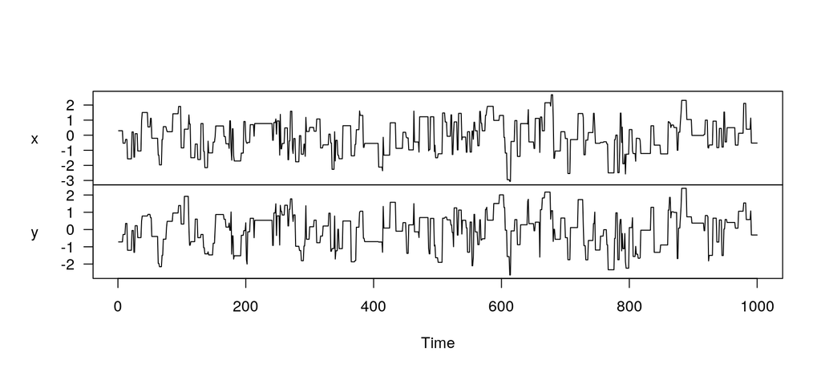

```r
colnames(xy) <- c("x", "y"); plot(as.ts(xy), main = "")
```

## Effective Sample Size of Markov Chain Output

- If a Markov Chain mixes fast enough for the MCMC CLT to hold, then
  - The Effective Sample Size is \(n_{eff} = \frac{S}{1 + 2\sum_{k=1}^\infty \rho_k}\), where \(\rho_k\) is the ex ante autocorrelation between two draws that are \(k\) iterations apart
  - The MCMC Standard Error of the mean of the \(S\) draws is \(\frac{\sigma}{\sqrt{n_{eff}}}\) where \(\sigma\) is the true posterio standard deviation
- If \(\rho_k = 0 \forall k\), then \(n_{eff} = S\) and the MCMC-SE is \(\frac{\sigma}{\sqrt{S}}\), so the Effective Sample Size is the number of INDEPENDENT draws that would be expected to estimate the posterior mean of some function with the same accuracy as the \(S\) DEPENDENT draws that you have from the posterior distribution
- Both have to be estimated and unfortunately, the estimator is not that reliable when the true Effective Sample Size is low (~5% of \(S\))
- For the Metropolis example, \(n_{eff}\) is estimated to be \(\approx 100\) for both margins

## Gibbs Samplers

- Metropolis-Hastings where \(q\left(\left.\theta_k^\prime\right|\dots\right) = f\left(\left.\theta_k^\prime\right|\boldsymbol{\theta}_{-k}\dots\right)\) and \(\boldsymbol{\theta}_{-k}\) consists of all elements of \(\boldsymbol{\theta}\) except the \(k\)-th
- \(\alpha^\ast = \mathrm{min}\{1,\frac{f\left(\left.\boldsymbol{\theta}^\prime\right|\dots\right)} {f\left(\left.\boldsymbol{\theta}\right|\dots\right)} \frac{f\left(\left.\theta_k\right|\boldsymbol{\theta}_{-k}\dots\right)} {f\left(\left.\theta_k^\prime\right|\boldsymbol{\theta}_{-k}\dots\right)}\} = \mathrm{min}\{1,\frac{f\left(\left.\theta_k^\prime\right|\boldsymbol{\theta}_{-k}\dots\right) f\left(\left.\boldsymbol{\theta}_{-k}\right|\dots\right)} {f\left(\left.\theta_k\right|\boldsymbol{\theta}_{-k}\dots\right) f\left(\left.\boldsymbol{\theta}_{-k}\right|\dots\right)} \frac{f\left(\left.\theta_k\right|\boldsymbol{\theta}_{-k}\dots\right)} {f\left(\left.\theta_k^\prime\right|\boldsymbol{\theta}_{-k}\dots\right)}\} = 1\) so \(\theta_k^\prime\) is ALWAYS accepted by construction. But \(\theta_k^\prime\) may be very close to \(\theta_k\) when the variance of the “full-conditional” distribution of \(\theta_k^\prime\) given \(\boldsymbol{\theta}_{-k}\) is small
- Can loop over \(k\) to draw sequentially from each full-conditional distribution
- Presumes that there is an algorithm to draw from the full-conditional distribution for each \(k\). Most times have to fall back to something else.

## Gibbs Sampling from the Bivariate Normal

In breakout rooms, write a `Gibbs_rng` function in the Stan language that draws \(S\) times from a bivariate normal distribution by repeatedly drawing from the normal distribution of \(Y \mid X\) and then the normal distribution of \(X \mid Y\)

```stan
functions { /* saved as Gibbs_rng.stan in R's working directory */
  matrix Gibbs_rng(int S, real mu_X, real mu_Y, real sigma_X, real sigma_Y, real rho) {
    matrix[S, 2] draws; real x = 0; // must initialize before loop so that it persists
    // define many constants
    for (s in 1:S) {
      // fill in this part
    }
  }
}
```

## Answer

```
functions { /* saved as Gibbs_rng.stan in R's working directory */
  matrix Gibbs_rng(int S, real mu_X, real mu_Y, real sigma_X, real sigma_Y, real rho) {
    matrix[S, 2] draws; real x = 0; // must initialize before loop so that it persists
    real beta = rho * sigma_Y / sigma_X;
    real lambda = rho * sigma_X / sigma_Y;
    real sqrt1mrho2 = sqrt(1 - square(rho));
    real sigma_YX = sigma_Y * sqrt1mrho2;
    real sigma_XY = sigma_X * sqrt1mrho2; // this is smaller than in binormal_rng.stan !
    for (s in 1:S) {
      real y = normal_rng(mu_Y + beta * (x - mu_X), sigma_YX); // y needs a persistent x
      x = normal_rng(mu_X + lambda * (y - mu_Y), sigma_XY); // overwritten not redeclared
      draws[s, ] = [x, y];
    } // y gets deleted here but x does not
    return draws;
  }
}
```

```r
rstan::expose_stan_functions("Gibbs_rng.stan")
```

## Autocorrelation of Gibbs Sampling: \(n_{eff} \approx 300\)

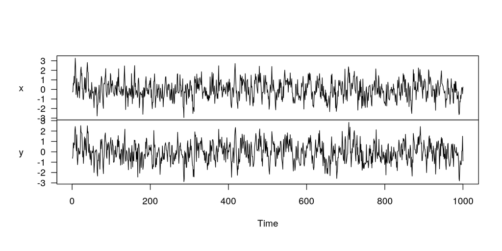

```r
xy <- Gibbs_rng(S, mu_X, mu_Y, sigma_X, sigma_Y, rho)
colnames(xy) <- c("x", "y")
plot(as.ts(xy), main = "")
```

## What the BUGS Software Family Essentially Does

```r
library(Runuran) # defines ur() which draws from the approximate ICDF via pinv.new()
BUGSish <- function(log_kernel, # function of theta outputting posterior log-kernel
                    theta,      # starting values for all the parameters
                    ...,        # additional arguments passed to log_kernel
                    LB = rep(-Inf, K), UB = rep(Inf, K), # optional bounds on theta
                    S = 1000) { # number of posterior draws to obtain
  K <- length(theta); draws <- matrix(NA, nrow = S, ncol = K)
  for(s in 1:S) { # these loops are slow, as is approximating the ICDF | theta[-k]
    for (k in 1:K) {
      full_conditional <- function(theta_k)
        return(log_kernel(c(head(theta, k - 1), theta_k, tail(theta, K - k)), ...))
      theta[k] <- ur(pinv.new(full_conditional, lb = LB[k], ub = UB[k], islog = TRUE,
                              uresolution = 1e-8, smooth = TRUE, center = theta[k]))
    }
    draws[s, ] <- theta
  }
  return(draws)
}
```

## Gibbs Sampling a la BUGS

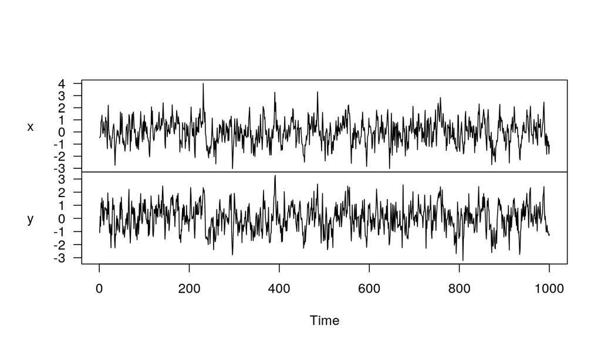

```r
rstan::expose_stan_functions("binormal_lpdf.stan")
xy <- BUGSish(binormal_lpdf, theta = c(0, 0),
              mu_X, mu_Y, sigma_X, sigma_Y, rho)
colnames(xy) <- c("x", "y")
plot(as.ts(xy), main = "")
```

## Comparing Stan to Historical MCMC Samplers

- Only requires user to specify numerator of Bayes Rule
- Unlike Gibbs sampling, proposals are joint
- Like Gibbs sampling, proposals always accepted
- Like Gibbs sampling, tuning of proposals is (often) not required
- Unlike Gibbs sampling, the effective sample size is typically 25% to 125% of the nominal number of draws from the posterior distribution because \(\rho_1\) can be negative in \(n_{eff} = \frac{S}{1 + 2\sum_{k=1}^\infty \rho_k}\)
- Unlike Gibbs sampling, Stan produces warning messages when things are not going swimmingly. Do not ignore these!
- Unlike BUGS, Stan does not permit discrete unknowns but even BUGS has difficulty drawing discrete unknowns with a sufficient amount of efficiency
- Metropolis-Hastings is another historical MCMC sampler that you may have heard about and Stan is always better than M-H

## Hamiltonian Monte Carlo

- Instead of simply drawing from the posterior distribution whose PDF is \(f\left(\left.\boldsymbol{\theta}\right|\mathbf{y}\dots\right) \propto f\left(\boldsymbol{\theta}\right) L\left(\boldsymbol{\theta};\mathbf{y}\right)\) Stan augments the “position” variables \(\boldsymbol{\theta}\) with an equivalent number of “momentum” variables \(\boldsymbol{\phi}\) and draws from \[f\left(\left.\boldsymbol{\theta}\right|\mathbf{y}\dots\right) \propto \int_{-\infty}^{\infty} \dots \int_{-\infty}^{\infty} \prod_{k=1}^K \frac{1}{\sigma_k\sqrt{2\pi}}e^{-\frac{1}{2}\left(\frac{\phi_k}{\sigma_k}\right)^2} f\left(\boldsymbol{\theta}\right) L\left(\boldsymbol{\theta};\mathbf{y}\right) d\phi_1 \dots d\phi_K\]
- Since the likelihood is NOT a function of \(\phi_k\), the posterior distribution of \(\phi_k\) is the same as its prior, which is normal with a “tuned” standard deviation. So, at the \(s\)-th MCMC iteration, we just draw each \(\widetilde{\phi}_k\) from its normal distribution.
- Using physics, the realizations of each \(\widetilde{\phi}_k\) at iteration \(s\) “push” \(\boldsymbol{\theta}\) from iteration \(s - 1\) through the parameter space whose topology is defined by the negated log-kernel of the posterior distribution: \(-\ln f\left(\boldsymbol{\theta}\right) - \ln L\left(\boldsymbol{\theta};\mathbf{y}\right)\)
- See HMC.R demo on Canvas

## Demo of Hamiltonian Monte Carlo

[interactive chart not shown]

## No U-Turn Sampling (NUTS)

- The location of \(\boldsymbol{\theta}\) moving according to Hamiltonian physics at any instant would be a valid draw from the posterior distribution
- But (in the absence of friction) \(\boldsymbol{\theta}\) moves indefinitely so when do you stop?
- [Hoffman and Gelman (2014)](http://www.stat.columbia.edu/~gelman/research/published/nuts.pdf) proposed stopping when there is a “U-turn” in the sense the footprints turn around and start to head in the direction they just came from. Hence, the name No U-Turn Sampling.
- After the U-Turn, one footprint is selected with probability proportional to the posterior kernel to be the realization of \(\boldsymbol{\theta}\) on iteration \(s\) and the process repeates itself
- NUTS discretizes a continuous-time Hamiltonian process in order to solve a system of Ordinary Differential Equations (ODEs), which requires a stepsize that is also tuned during the warmup phase
- [Video](https://www.youtube.com/watch?time_continue=1&v=qxCQoZC0CVY&feature=emb_logo) and R [code](https://github.com/andrewGhazi/funstuff/blob/master/R/nuts.R)

## Using Stan via R

1. Write the program in a (text) .stan file w/ R-like syntax that ultimately defines a posterior log-kernel. We will not do this until May. Stan’s parser, `rstan::stanc`, does two things
   - checks that program is syntactically valid and tells you if not
   - writes a conceptually equivalent C++ source file to disk
2. C++ compiler creates a binary file from the C++ source
3. Execute the binary from R (can be concurrent with 2)
4. Analyze the resulting samples from the posterior
   - Posterior predictive checks
   - Model comparison
   - Decision

## Drawing from a Posterior Distribution with NUTS

```r
library(rstan)
post <- stan("coronavirus.stan", refresh = 0,
             data = list(n = n, y = y, m = 0.3, IQR = 0.1,
                         asymmetry = a_s[1], steepness = a_s[2]))
post
```

```
## Inference for Stan model: coronavirus.
## 4 chains, each with iter=2000; warmup=1000; thin=1;
## post-warmup draws per chain=1000, total post-warmup draws=4000.
##
##        mean se_mean   sd  2.5%   25%   50%   75%  97.5% n_eff Rhat
## p      0.79    0.00 0.10  0.56  0.73  0.81  0.87   0.94  1397    1
## theta  0.37    0.00 0.03  0.31  0.35  0.37  0.39   0.43  1286    1
## y_    82.71    0.22 9.87 63.00 76.00 82.00 89.00 103.00  2016    1
## lp__  -5.31    0.02 0.73 -7.37 -5.49 -5.03 -4.85  -4.81  1577    1
##
## Samples were drawn using NUTS(diag_e) at Mon Apr  6 02:39:50 2020.
## For each parameter, n_eff is a crude measure of effective sample size,
## and Rhat is the potential scale reduction factor on split chains (at
## convergence, Rhat=1).
```